# Analysis of impact of weather events across US.

Pedro A. Alonso Baigorri

16 de junio de 2017

## Synopsis

Storms and other severe weather events can cause both public health and economic problems for communities and municipalities. Many severe events can result in fatalities, injuries, and property damage, and preventing such outcomes to the extent possible is a key concern.

This analysis involves exploring the U.S. National Oceanic and Atmospheric Administration’s (NOAA) storm database. This database tracks characteristics of major storms and weather events in the United States, including when and where they occur, as well as estimates of any fatalities, injuries, and property damage.

The purpose of this analysis is to find out what are the type of weather events with more impact across the United States. The analysis of the impact will include, impact in the general population (including injuries and fatalities), and also economic impact.

This document will contain not only the analysis done but also the code and data required to this analyis. The reason for this is to make it reproducible for other researchers.

Final conclusions will be supported by plots as a result of the analysis performed.

All the analysis has been done using R.

## Data processing

### Initial setup

First step for data processing is to load the main packages and setting my working environment.

```r
# setting the working path
setwd(".")


# Load required libraries
library(dplyr)
library(stringr)
library(ggplot2)
```

### Getting the data

Now, the next steps is to obtain and load the data from the official repositority at: https://d396qusza40orc.cloudfront.net/repdata%2Fdata%2FStormData.csv.bz2"

```r
fileURL <- "https://d396qusza40orc.cloudfront.net/repdata%2Fdata%2FStormData.csv.bz2"
localFile <- "./data/storm.zip"
destFile <- "./data/storm.csv"


if (!file.exists(localFile))
{
    if (!file.exists("./data")){dir.create("./data")}

    download.file(fileURL, localFile)
    bunzip2(localFile, destFile, remove = FALSE )
}

storms <- read.csv(destFile)

dim(storms)
```

```
## [1] 902297     37
```

```r
str(storms)
```

```
## 'data.frame':    902297 obs. of  37 variables:
##  $ STATE__   : num  1 1 1 1 1 1 1 1 1 1 ...
##  $ BGN_DATE  : Factor w/ 16335 levels "1/1/1966 0:00:00",..: 6523 6523 4242 11116 2224 2224 2260 383 3980 3980 ...
##  $ BGN_TIME  : Factor w/ 3608 levels "00:00:00 AM",..: 272 287 2705 1683 2584 3186 242 1683 3186 3186 ...
##  $ TIME_ZONE : Factor w/ 22 levels "ADT","AKS","AST",..: 7 7 7 7 7 7 7 7 7 7 ...
##  $ COUNTY    : num  97 3 57 89 43 77 9 123 125 57 ...
##  $ COUNTYNAME: Factor w/ 29601 levels "","5NM E OF MACKINAC BRIDGE TO PRESQUE ISLE LT MI",..: 13513 1873 4598 10592 4372 10094 1973 23873 24418 4598 ...
##  $ STATE     : Factor w/ 72 levels "AK","AL","AM",..: 2 2 2 2 2 2 2 2 2 2 ...
##  $ EVTYPE    : Factor w/ 985 levels "   HIGH SURF ADVISORY",..: 834 834 834 834 834 834 834 834 834 834 ...
##  $ BGN_RANGE : num  0 0 0 0 0 0 0 0 0 0 ...
##  $ BGN_AZI   : Factor w/ 35 levels "","  N"," NW",..: 1 1 1 1 1 1 1 1 1 1 ...
##  $ BGN_LOCATI: Factor w/ 54429 levels "","- 1 N Albion",..: 1 1 1 1 1 1 1 1 1 1 ...
##  $ END_DATE  : Factor w/ 6663 levels "","1/1/1993 0:00:00",..: 1 1 1 1 1 1 1 1 1 1 ...
##  $ END_TIME  : Factor w/ 3647 levels ""," 0900CST",..: 1 1 1 1 1 1 1 1 1 1 ...
##  $ COUNTY_END: num  0 0 0 0 0 0 0 0 0 0 ...
```

[output cut: 23 more lines]

### Subsetting the dataset

According to the documentation the official event Types were changed in Jan 1996. Before of this change, the number of different types was very small. So, I’ll focus the analysis only in the events occured after Jan 1996.

In addition I will select only the columns of interest for the analysis:

EVTYPE, FATALITIES, INJURIES, PROPDMG, PROPDMGEXP, CROPDMG, CROPDMGEXP

```r
# filtering data before of jan 1996
head(storms$BGN_DATE)
```

```
## [1] 4/18/1950 0:00:00  4/18/1950 0:00:00  2/20/1951 0:00:00
## [4] 6/8/1951 0:00:00   11/15/1951 0:00:00 11/15/1951 0:00:00
## 16335 Levels: 1/1/1966 0:00:00 1/1/1972 0:00:00 ... 9/9/2011 0:00:00
```

```r
storms$date <- as.Date(storms$BGN_DATE, "%m/%d/%Y")
head(storms$date)
```

```
## [1] "1950-04-18" "1950-04-18" "1951-02-20" "1951-06-08" "1951-11-15"
## [6] "1951-11-15"
```

```r
storms <- subset(storms, date > as.Date("12/31/1995", "%m/%d/%Y"))
dim(storms)
```

```
## [1] 653530     38
```

```r
min(storms$date)
```

```
## [1] "1996-01-01"
```

```r
#selecting only the columns of interest
myvars <- c("EVTYPE", "FATALITIES", "INJURIES",
             "PROPDMG", "PROPDMGEXP", "CROPDMG",
             "CROPDMGEXP")
storms <- subset(storms, select = myvars)
colnames(storms) <- myvars

dim(storms)
```

```
## [1] 653530      7
```

### Fixing the typos of event type column

I have observed that the values in the column EVTYPE have different typo erros such as uppercases and whitespaces. So some basic operations have performed to fix these problems.

```r
length(unique(storms$EVTYPE))
```

```
## [1] 516
```

```r
# transforming to uppercase
storms$EVTYPE <- toupper(storms$EVTYPE)
length(unique(storms$EVTYPE))
```

```
## [1] 438
```

```r
#removing starting white spaces
storms$EVTYPE <- trimws(storms$EVTYPE)
length(unique(storms$EVTYPE))
```

```
## [1] 430
```

### Setting the right value to damage variables

The values of the economic damages are affected by an multiplier included in the columns PROPDMGEXP and CROPDMGEXP (for damages in PROPERTIES and DROPS).

The value of the multiplier is obtained from the following article:

https://rstudio-pubs-static.s3.amazonaws.com/58957_37b6723ee52b455990e149edde45e5b6.html

The next code shows the processing required to calculate the total value with the corresponding multiplier.

```r
levels(storms$PROPDMGEXP)
```

```
##  [1] ""  "-" "?" "+" "0" "1" "2" "3" "4" "5" "6" "7" "8" "B" "h" "H" "K"
## [18] "m" "M"
```

```r
#symbols are multipler of 0 except + that is 1
storms$PROPDMGEXP_VALUE[storms$PROPDMGEXP == ""] <- 0
storms$PROPDMGEXP_VALUE[storms$PROPDMGEXP == "-"] <- 0
storms$PROPDMGEXP_VALUE[storms$PROPDMGEXP == "?"] <- 0
storms$PROPDMGEXP_VALUE[storms$PROPDMGEXP == "+"] <- 1

# numbers from 0-9 are multiplier of 10 according to coursera forum article
# https://rstudio-pubs-static.s3.amazonaws.com/58957_37b6723ee52b455990e149edde45e5b6.html
storms$PROPDMGEXP_VALUE[storms$PROPDMGEXP == "0"] <- 10
storms$PROPDMGEXP_VALUE[storms$PROPDMGEXP == "1"] <- 10
storms$PROPDMGEXP_VALUE[storms$PROPDMGEXP == "2"] <- 10
storms$PROPDMGEXP_VALUE[storms$PROPDMGEXP == "3"] <- 10
storms$PROPDMGEXP_VALUE[storms$PROPDMGEXP == "4"] <- 10
storms$PROPDMGEXP_VALUE[storms$PROPDMGEXP == "5"] <- 10
storms$PROPDMGEXP_VALUE[storms$PROPDMGEXP == "6"] <- 10
storms$PROPDMGEXP_VALUE[storms$PROPDMGEXP == "7"] <- 10
storms$PROPDMGEXP_VALUE[storms$PROPDMGEXP == "8"] <- 10
storms$PROPDMGEXP_VALUE[storms$PROPDMGEXP == "9"] <- 10

#then standard currency symbols
storms$PROPDMGEXP_VALUE[storms$PROPDMGEXP == "B"] <- 1000000000
storms$PROPDMGEXP_VALUE[storms$PROPDMGEXP == "h"] <- 100
storms$PROPDMGEXP_VALUE[storms$PROPDMGEXP == "H"] <- 100
storms$PROPDMGEXP_VALUE[storms$PROPDMGEXP == "K"] <- 1000
storms$PROPDMGEXP_VALUE[storms$PROPDMGEXP == "m"] <- 1000
storms$PROPDMGEXP_VALUE[storms$PROPDMGEXP == "M"] <- 1000

storms$PROPDMGEXP_VALUE <- storms$PROPDMGEXP_VALUE * storms$PROPDMG

#and now for CROPS
levels(storms$CROPDMGEXP)
```

```
## [1] ""  "?" "0" "2" "B" "k" "K" "m" "M"
```

```r
storms$CROPDMGEXP_VALUE[storms$CROPDMGEXP == ""] <- 0
storms$CROPDMGEXP_VALUE[storms$CROPDMGEXP == "?"] <- 0
storms$CROPDMGEXP_VALUE[storms$CROPDMGEXP == "0"] <- 10
storms$CROPDMGEXP_VALUE[storms$CROPDMGEXP == "2"] <- 10
storms$CROPDMGEXP_VALUE[storms$CROPDMGEXP == "B"] <- 1000000000
storms$CROPDMGEXP_VALUE[storms$CROPDMGEXP == "k"] <- 1000
storms$CROPDMGEXP_VALUE[storms$CROPDMGEXP == "K"] <- 1000
storms$CROPDMGEXP_VALUE[storms$CROPDMGEXP == "m"] <- 1000
storms$CROPDMGEXP_VALUE[storms$CROPDMGEXP == "M"] <- 1000

storms$CROPDMGEXP_VALUE <- storms$CROPDMGEXP_VALUE * storms$CROPDMG

head(storms)
```

```
##              EVTYPE FATALITIES INJURIES PROPDMG PROPDMGEXP CROPDMG
## 248768 WINTER STORM          0        0     380          K      38
## 248769      TORNADO          0        0     100          K       0
## 248770    TSTM WIND          0        0       3          K       0
## 248771    TSTM WIND          0        0       5          K       0
## 248772    TSTM WIND          0        0       2          K       0
## 248773         HAIL          0        0       0                  0
##        CROPDMGEXP PROPDMGEXP_VALUE CROPDMGEXP_VALUE
## 248768          K           380000            38000
## 248769                      100000                0
## 248770                        3000                0
## 248771                        5000                0
## 248772                        2000                0
## 248773                           0                0
```

## Analysis

Once the preprocessing is finished the dataset is ready for the analysis.

The following analysis are performed:

- Analysis of fatalities
- Analysis of injuries
- Analysis of economic impact

### Analysis of fatalities

The following plot represent the top 10 types of events with more fatalites:

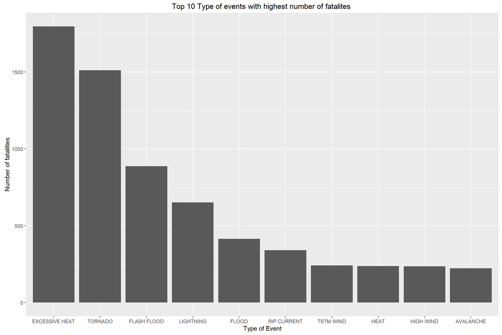

```r
fatalities <- aggregate(FATALITIES ~ EVTYPE, data = storms, FUN = sum )

fatalities <- fatalities[order(-fatalities$FATALITIES),]

top10 <- fatalities[1:10, ]


ggplot(top10, aes(x=reorder(EVTYPE, -FATALITIES), y=FATALITIES)) + geom_bar(stat="identity") +
    labs(title="Top 10 Type of events with highest number of fatalites ", x="Type of Event", y="Number of fatalities")
```

```r
fatalities_type <- top10[1, "EVTYPE"]
```

### Analysis of injuries

The following plot represent the top 10 types of events with more injuries:

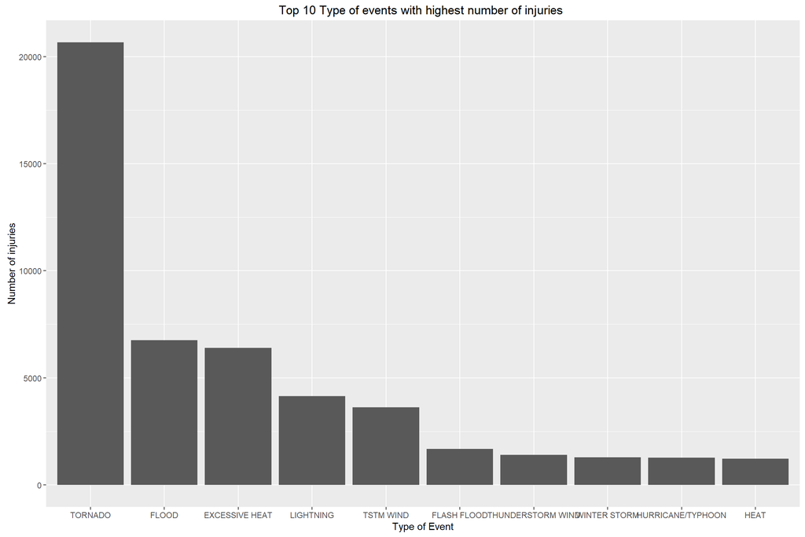

```r
injuries <- aggregate(INJURIES ~ EVTYPE, data = storms, FUN = sum )

injuries <- injuries[order(-injuries$INJURIES),]

top10 <- injuries[1:10, ]

ggplot(top10, aes(x=reorder(EVTYPE, -INJURIES), y=INJURIES)) + geom_bar(stat="identity") +
    labs(title="Top 10 Type of events with highest number of injuries ", x="Type of Event", y="Number of injuries")
```

```r
injuries_type <- top10[1, "EVTYPE"]
```

### Analysis of economic damages

The following plot represent the top 10 types of events with more economic damages:

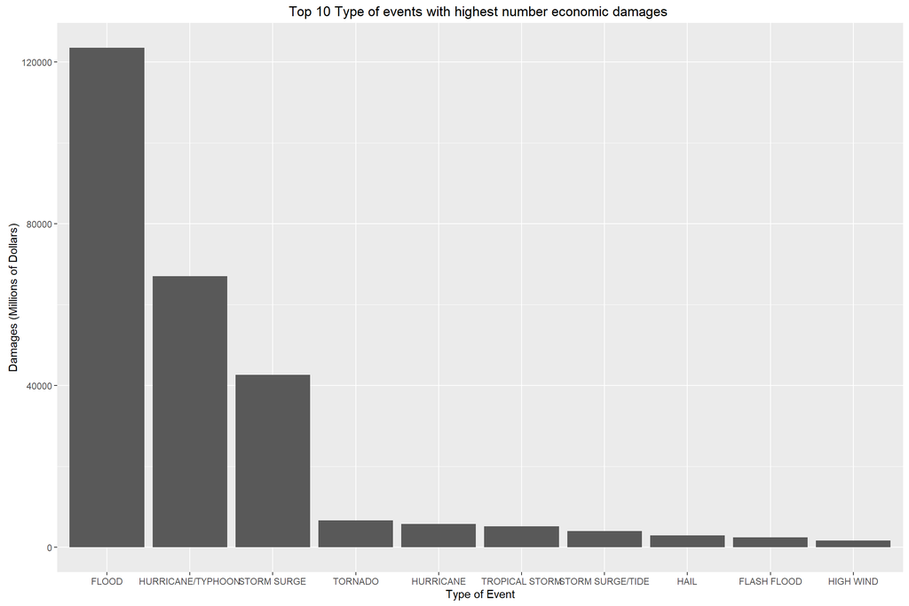

```r
storms$TOTAL_DAMAGES = (storms$PROPDMGEXP_VALUE + storms$CROPDMGEXP_VALUE)


eco <- aggregate(TOTAL_DAMAGES ~ EVTYPE, data = storms, FUN = sum )

eco <- eco[order(-eco$TOTAL_DAMAGES),]

top10 <- eco[1:10, ]

ggplot(top10, aes(x=reorder(EVTYPE, -TOTAL_DAMAGES), y=TOTAL_DAMAGES/1000000)) +
    geom_bar(stat="identity") +
    labs(title="Top 10 Type of events with highest number economic damages ", x="Type of Event", y="Damages (Millions of Dollars)")
```

```r
economic_type <- top10[1, "EVTYPE"]
```

## Conclusions

The analysis concludes that:

- The event type with more impact in Injuries is: TORNADO
- The event type with more impact in Fatalities is: EXCESSIVE HEAT
- The event type with more Economic impact is: FLOOD